# International Trade Network Analysis (2012 - 2021)

## Community Detection

**Community detection hekps in identify karge scake patterns in networks. Here we will use undirected and random walk methods to compare the modularity basis various number of steps with walktrap.**

```r
net.ig.undirected <- as.undirected(net.ig)
names(cluster_fast_greedy(net.ig.undirected))
```

```
[1] "merges"     "modularity" "membership" "names"      "algorithm"
[6] "vcount"
```

```r
cluster_fast_greedy(net.ig.undirected)
```

```
IGRAPH clustering fast greedy, groups: 3, mod: 0.15
+ groups:
  $`1`
   [1] "Germany"               "Russian Federation"
   [3] "Bulgaria"              "Austria"
   [5] "Belgium"               "Finland"
   [7] "Morocco"               "Switzerland"
   [9] "Poland"                "Uruguay"
  [11] "Italy"                 "Sweden"
  [13] "Kazakhstan"            "Portugal"
  [15] "Turkey"                "Ghana"
  [17] "Armenia"               "Afghanistan"
  + ... omitted several groups/vertices
```

```r
igraph::groups(cluster_fast_greedy(net.ig.undirected))
```

```
$`1`
 [1] "Germany"               "Russian Federation"
 [3] "Bulgaria"              "Austria"
 [5] "Belgium"               "Finland"
 [7] "Morocco"               "Switzerland"
 [9] "Poland"                "Uruguay"
[11] "Italy"                 "Sweden"
[13] "Kazakhstan"            "Portugal"
[15] "Turkey"                "Ghana"
[17] "Armenia"               "Afghanistan"
[19] "Algeria"               "Azerbaijan"
[21] "Bosnia Herzegovina"    "Belarus"
[23] "Croatia"               "Cyprus"
[25] "Czechia"               "Denmark"
[27] "Estonia"               "Faeroe Isds"
```

[output cut: 160 more lines]

Exploring Community Density

```r
print(blockmodel(matrix, cluster_fast_greedy(net.ig.undirected)$membership)$block.model/1000000, digits = 2)
```

```
        Block 1 Block 2 Block 3
Block 1    6.41     6.5     1.1
Block 2    0.85    17.9     5.4
Block 3   10.33    74.8    42.2
```

```r
cluster_fast_greedy(net.ig.undirected)$membership
```

```
  [1] 3 1 3 2 3 2 2 1 2 3 1 3 3 3 3 3 3 3 3 1 1 3 1 3 3 3 3 1 2 1 1 1
 [33] 1 1 3 1 3 2 1 2 1 2 1 2 3 3 3 3 2 2 1 1 2 1 2 1 3 2 1 1 2 3 1 2
 [65] 1 1 2 1 1 1 1 1 1 3 3 2 1 1 1 3 1 2 2 2 1 2 1 1 1 2 1 1 1 2 3 3
 [97] 2 1 2 3 2 1 1 1 2 1 1 1 1 2 3 2 3 2 1 1 1 1 2 3 1 3 1 2 2 3 2 1
[129] 1 2 3 1 2 1 2 3 3 3 2 3 3 2 2 2 3 1 3 2 2 2 2 3 3 3 3 3 3 3 3 2
[161] 3 3 3 3 3 3 3 3 2 2 2 2 2 3 2 2 2 2 1 2 2 1 1 1 2 1 1 1 3 3 3 2
[193] 1 1 2 3 2 2 3 3 3 3 3 3 2
```

```r
cluster_fast_greedy(net.ig.undirected)$names
```

```
  [1] "Chile"
  [2] "Germany"
  [3] "Japan"
  [4] "Congo"
  [5] "USA"
  [6] "China"
  [7] "Zambia"
  [8] "Russian Federation"
  [9] "Australia"
 [10] "Bolivia (Plurinational State of)"
 [11] "Bulgaria"
 [12] "Canada"
 [13] "Rep. of Korea"
 [14] "Other Asia, nes"
 [15] "Peru"
```

[output cut: 190 more lines]

```r
membership(cluster_fast_greedy(net.ig.undirected))
```

```
                                 Chile
                                     3
                               Germany
                                     1
                                 Japan
                                     3
                                 Congo
                                     2
                                   USA
                                     3
                                 China
                                     2
                                Zambia
                                     2
                    Russian Federation
                                     1
                             Australia
                                     2
      Bolivia (Plurinational State of)
                                     3
                              Bulgaria
                                     1
                                Canada
                                     3
                         Rep. of Korea
                                     3
                       Other Asia, nes
                                     3
                                  Peru
                                     3
                                 India
                                     3
                                 Spain
                                     3
                            Areas, nes
                                     3
                             Argentina
                                     3
                               Austria
                                     1
```

[output cut: 355 more lines]

```
                                     2
                Br. Indian Ocean Terr.
                                     3
                             Greenland
                                     3
                        Christmas Isds
                                     3
                      French Polynesia
                                     3
                                Tuvalu
                                     3
                         Guinea-Bissau
                                     3
                              Eswatini
                                     2
```

```r
V(net.ig)$name
```

```
  [1] "Chile"
  [2] "Germany"
  [3] "Japan"
  [4] "Congo"
  [5] "USA"
  [6] "China"
  [7] "Zambia"
  [8] "Russian Federation"
  [9] "Australia"
 [10] "Bolivia (Plurinational State of)"
 [11] "Bulgaria"
 [12] "Canada"
 [13] "Rep. of Korea"
 [14] "Other Asia, nes"
 [15] "Peru"
```

[output cut: 190 more lines]

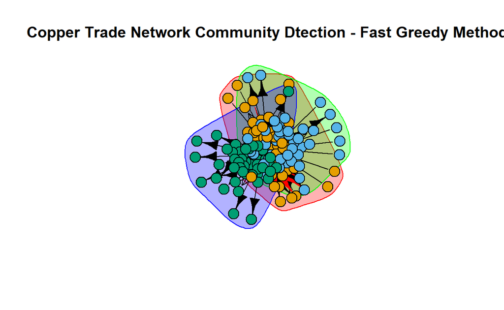

```r
plot(cluster_fast_greedy(net.ig.undirected), net.ig, vertex.label = NA, main = "Copper Trade Network Community Dtection - Fast Greedy Method")
```

```r
trade.wt <- walktrap.community(net.ig)
```

```r
igraph::groups(trade.wt)
```

```
$`1`
  [1] "Chile"
  [2] "Germany"
  [3] "Japan"
  [4] "Congo"
  [5] "USA"
  [6] "China"
  [7] "Zambia"
  [8] "Russian Federation"
  [9] "Australia"
 [10] "Bolivia (Plurinational State of)"
 [11] "Bulgaria"
 [12] "Canada"
 [13] "Rep. of Korea"
 [14] "Other Asia, nes"
```

[output cut: 191 more lines]

```r
igraph::groups(walktrap.community(net.ig, steps = 10))
```

```
$`1`
  [1] "Chile"
  [2] "Germany"
  [3] "Japan"
  [4] "Congo"
  [5] "USA"
  [6] "China"
  [7] "Zambia"
  [8] "Russian Federation"
  [9] "Australia"
 [10] "Bolivia (Plurinational State of)"
 [11] "Bulgaria"
 [12] "Canada"
 [13] "Rep. of Korea"
 [14] "Other Asia, nes"
```

[output cut: 191 more lines]

```r
igraph::groups(walktrap.community(net.ig, steps = 20))
```

```
$`1`
  [1] "Chile"
  [2] "Germany"
  [3] "Japan"
  [4] "Congo"
  [5] "USA"
  [6] "China"
  [7] "Zambia"
  [8] "Russian Federation"
  [9] "Australia"
 [10] "Bolivia (Plurinational State of)"
 [11] "Bulgaria"
 [12] "Canada"
 [13] "Rep. of Korea"
 [14] "Other Asia, nes"
```

[output cut: 191 more lines]

```r
igraph::groups(walktrap.community(net.ig, steps = 100))
```

```
$`1`
  [1] "Chile"
  [2] "Germany"
  [3] "Japan"
  [4] "Congo"
  [5] "USA"
  [6] "China"
  [7] "Zambia"
  [8] "Russian Federation"
  [9] "Australia"
 [10] "Bolivia (Plurinational State of)"
 [11] "Bulgaria"
 [12] "Canada"
 [13] "Rep. of Korea"
 [14] "Other Asia, nes"
```

[output cut: 191 more lines]

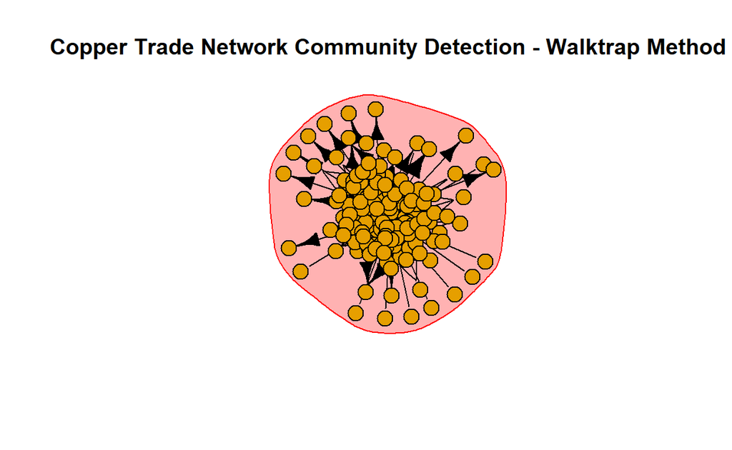

```r
plot(trade.wt, net.ig, vertex.label=NA, main = "Copper Trade Network Community Detection - Walktrap Method")
```

```r
modularity(cluster_fast_greedy(net.ig.undirected))
```

```
[1] 0.1516442
```

```r
modularity(trade.wt)
```

```
[1] 0.002815393
```

```r
compare.algs<-function(alg.a,alg.b,compare.meth=c("vi", "nmi", "split.join", "rand", "adjusted.rand")){
  #create list of community objects and methods
  comm.compare<-expand.grid(alg.a=alg.a, alg.b=alg.b, meth=compare.meth, result=NA, stringsAsFactors = FALSE)
  #compare community partitions using a loop
for(i in 1:nrow(comm.compare)){
  comm1<-get(comm.compare$alg.a[i])
  comm2<-get(comm.compare$alg.b[i])
  method<-comm.compare$meth[i]
  comm.compare$result[i]<-compare(comm1, comm2, method)
}
  return(comm.compare)
}
```

```r
#compare community partitions
trade.fg <- cluster_fast_greedy(net.ig.undirected)
compare.algs(alg.a=c("trade.fg"),alg.b="trade.wt")
```

```
     alg.a    alg.b          meth       result
1 trade.fg trade.wt            vi 1.097578e+00
2 trade.fg trade.wt           nmi 0.000000e+00
3 trade.fg trade.wt    split.join 1.340000e+02
4 trade.fg trade.wt          rand 3.307508e-01
5 trade.fg trade.wt adjusted.rand 8.294542e-17
```

**Basis the “slit.join” score (1.340000e+02), we can conclude that the resulting partitions are less similar to each other. Rand Index indicates that the proportion of times that the two partitioning methods agree that two nodes belong in the same community is about 0.331.**

## Leading Label Propogation

```r
#Run clustering algorithm: leading label
trade.lab<-label.propagation.community(net.ig)
#Inspect community membership
igraph::groups(trade.lab)
```

```
$`1`
  [1] "Chile"
  [2] "Germany"
  [3] "Japan"
  [4] "Congo"
  [5] "USA"
  [6] "China"
  [7] "Zambia"
  [8] "Russian Federation"
  [9] "Australia"
 [10] "Bolivia (Plurinational State of)"
 [11] "Bulgaria"
 [12] "Canada"
 [13] "Rep. of Korea"
 [14] "Other Asia, nes"
```

[output cut: 235 more lines]

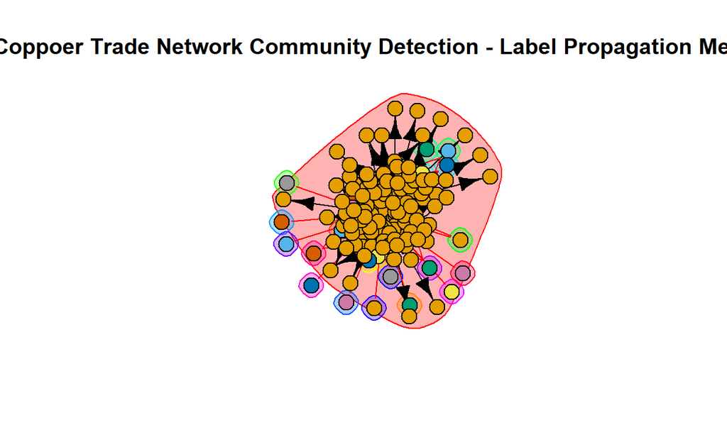

```r
plot(trade.lab, net.ig, vertex.label = NA, main = "Coppoer Trade Network Community Detection - Label Propagation Method")
```

```r
compare.algs(alg.a=c("trade.fg", "trade.wt"),alg.b="trade.lab")
```

```
      alg.a     alg.b          meth       result
1  trade.fg trade.lab            vi 1.531512e+00
2  trade.wt trade.lab            vi 6.725906e-01
3  trade.fg trade.lab           nmi 1.348219e-01
4  trade.wt trade.lab           nmi 0.000000e+00
5  trade.fg trade.lab    split.join 1.380000e+02
6  trade.wt trade.lab    split.join 2.200000e+01
7  trade.fg trade.lab          rand 4.009087e-01
8  trade.wt trade.lab          rand 7.964132e-01
9  trade.fg trade.lab adjusted.rand 2.072222e-03
10 trade.wt trade.lab adjusted.rand 0.000000e+00
```

```r
#Run clustering algorithm: edge betweenness
trade.edge<-label.propagation.community(net.ig)


#Inspect community membership
igraph::groups(trade.edge)
```

```
$`1`
  [1] "Chile"
  [2] "Germany"
  [3] "Japan"
  [4] "Congo"
  [5] "USA"
  [6] "China"
  [7] "Zambia"
  [8] "Russian Federation"
  [9] "Australia"
 [10] "Bolivia (Plurinational State of)"
 [11] "Bulgaria"
 [12] "Canada"
 [13] "Rep. of Korea"
 [14] "Other Asia, nes"
```

[output cut: 235 more lines]

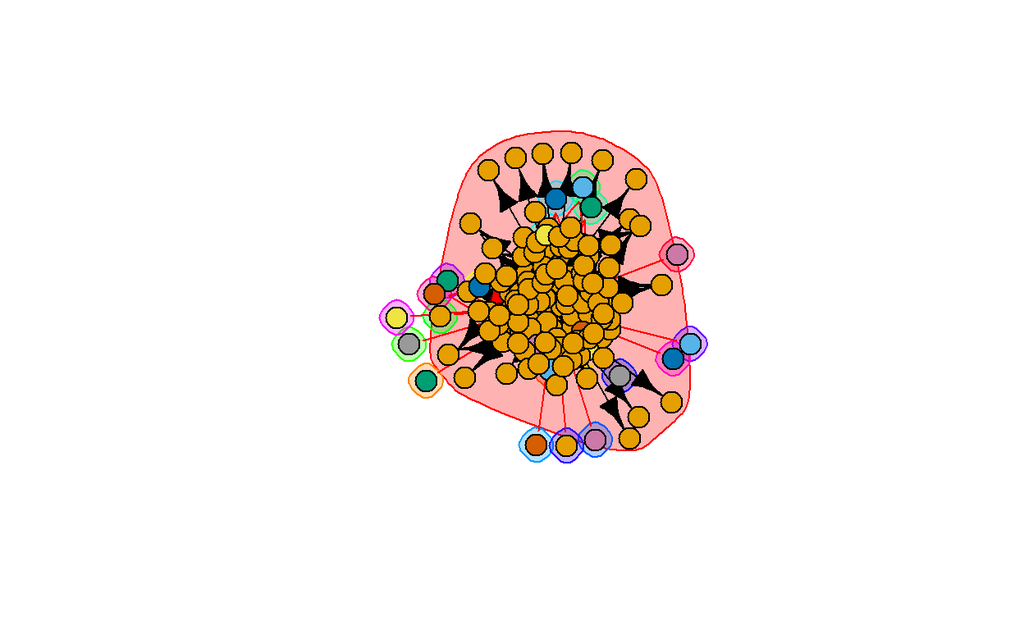

```r
plot(trade.edge, net.ig, vertex.label = NA, mail = "Copper Trade Network - Edge Betweeness Community Detection" )
```

```r
compare.algs(alg.a=c("trade.fg", "trade.wt", "trade.lab"),alg.b="trade.edge")
```

```
       alg.a      alg.b          meth       result
1   trade.fg trade.edge            vi 1.531512e+00
2   trade.wt trade.edge            vi 6.725906e-01
3  trade.lab trade.edge            vi 0.000000e+00
4   trade.fg trade.edge           nmi 1.348219e-01
5   trade.wt trade.edge           nmi 0.000000e+00
6  trade.lab trade.edge           nmi 1.000000e+00
7   trade.fg trade.edge    split.join 1.380000e+02
8   trade.wt trade.edge    split.join 2.200000e+01
9  trade.lab trade.edge    split.join 0.000000e+00
10  trade.fg trade.edge          rand 4.009087e-01
11  trade.wt trade.edge          rand 7.964132e-01
12 trade.lab trade.edge          rand 1.000000e+00
13  trade.fg trade.edge adjusted.rand 2.072222e-03
14  trade.wt trade.edge adjusted.rand 0.000000e+00
15 trade.lab trade.edge adjusted.rand 1.000000e+00
```